# What Associates With More Job Offers?

Exploring University Student Behaviours and Attributes

Sia Chawla, Tran Dang Huy (Andy), Jiaqi Xu (Jackie)

## Introduction

**Graduate Employment in Australia (2023-2024)**

According to [ABS](https://www.abs.gov.au/statistics/people/education/education-and-work-australia/latest-release) and [Ministers of the Education Portfolio](https://ministers.education.gov.au/clare/graduate-employment-rates-hit-highest-level-more-decade):

- **84%** of Australians with a `non-school qualification` in 2023 were employed in 2024.
- **78.5%** of `domestic graduates` and **57.7%** of `international graduates` found full-time job 4-6 months after graduation

These high employment rates suggest that **academic grades alone may no longer be the key differentiator** in job outcomes.

**Research Question**

**What student behaviours, attributes, or practices are most associated with receiving more job offers?**

## Dataset Description

**Data Source**

Kaggle - [Education and Career Success](https://www.kaggle.com/datasets/adilshamim8/education-and-career-success)

```
Rows: 5,000
Columns: 20
$ Student_ID            <chr> "S00001", "S00002", "S00003", "S00004", "S00005"…
$ Age                   <int> 24, 21, 28, 25, 22, 24, 27, 20, 24, 28, 28, 25, …
$ Gender                <chr> "Male", "Other", "Female", "Male", "Male", "Male…
$ High_School_GPA       <dbl> 3.58, 2.52, 3.42, 2.43, 2.08, 2.40, 2.36, 2.68, …
$ SAT_Score             <int> 1052, 1211, 1193, 1497, 1012, 1600, 1011, 1074, …
$ University_Ranking    <int> 291, 112, 715, 170, 599, 631, 610, 240, 337, 138…
$ University_GPA        <dbl> 3.96, 3.63, 2.63, 2.81, 2.48, 3.78, 3.83, 2.84, …
$ Field_of_Study        <chr> "Arts", "Law", "Medicine", "Computer Science", "…
$ Internships_Completed <int> 3, 4, 4, 3, 4, 2, 0, 1, 2, 1, 2, 2, 2, 0, 1, 3, …
$ Projects_Completed    <int> 7, 7, 8, 9, 6, 3, 1, 5, 3, 5, 7, 2, 0, 4, 2, 5, …
$ Certifications        <int> 2, 3, 1, 1, 4, 2, 3, 5, 0, 3, 5, 3, 5, 3, 3, 2, …
$ Soft_Skills_Score     <int> 9, 8, 1, 10, 10, 2, 3, 5, 5, 10, 8, 2, 2, 8, 1, …
$ Networking_Score      <int> 8, 1, 9, 6, 9, 2, 3, 1, 5, 2, 1, 9, 9, 6, 8, 9, …
$ Job_Offers            <int> 5, 4, 0, 1, 4, 1, 2, 2, 2, 0, 5, 5, 2, 2, 1, 3, …
$ Starting_Salary       <dbl> 27200, 25000, 42400, 57400, 47600, 68400, 55500,…
$ Career_Satisfaction   <int> 4, 1, 9, 7, 9, 9, 7, 2, 2, 4, 9, 7, 9, 4, 9, 7, …
$ Years_to_Promotion    <int> 5, 1, 3, 5, 5, 2, 4, 3, 2, 2, 1, 4, 4, 3, 3, 4, …
$ Current_Job_Level     <chr> "Entry", "Mid", "Entry", "Mid", "Entry", "Entry"…
$ Work_Life_Balance     <int> 7, 7, 7, 5, 2, 8, 3, 3, 2, 2, 2, 6, 8, 3, 6, 3, …
$ Entrepreneurship      <chr> "No", "No", "No", "No", "No", "Yes", "No", "No",…
```

This dataset contains categorical, discrete count, and continuous variables.

- Demographic
- Academic Performance
- Skills and Experiences
- Career Outcome

The outcome, `Job_Offers`, is a counting variable

## Methodology

**Data Exploration**:

- Rows with `Gender = "Other"` (3.8%) are excluded due to small sample size

**Variable Importance**:

- `Random forest` with `permutation`
  - Handles mixed data types
  - Captures not just linear relationships

**Direction of Association**:

- `Boxplot` and `scatterplot`
  - Suitable for count data
  - Show group-wise patterns

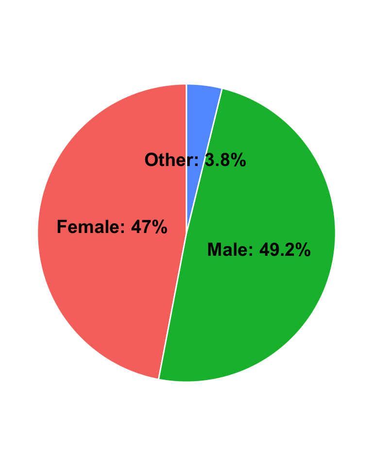

Figure 1: Distribution of Gender

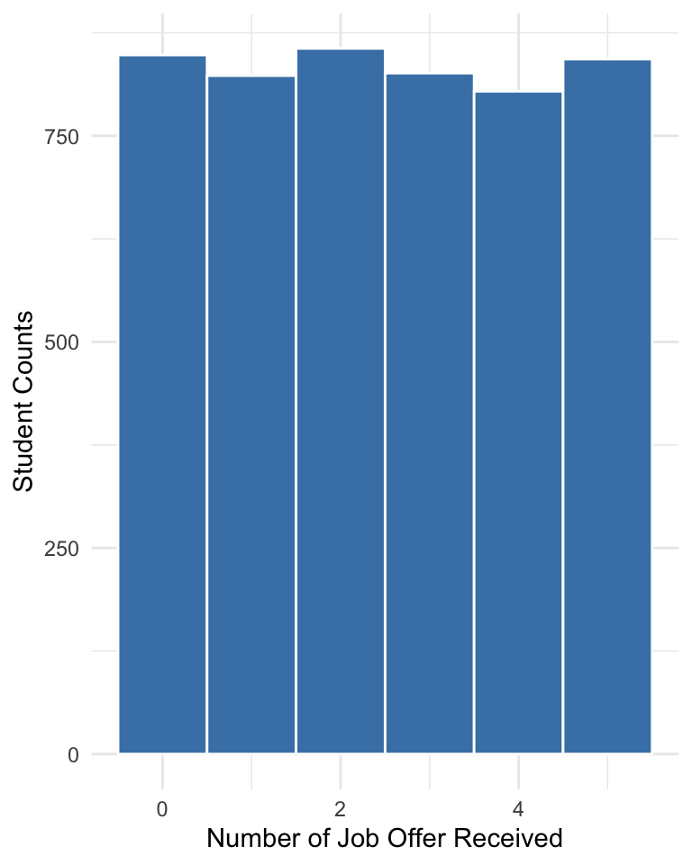

Figure 2: Distributions of Outcome Variable

## Elements that contribute to receiving job offers

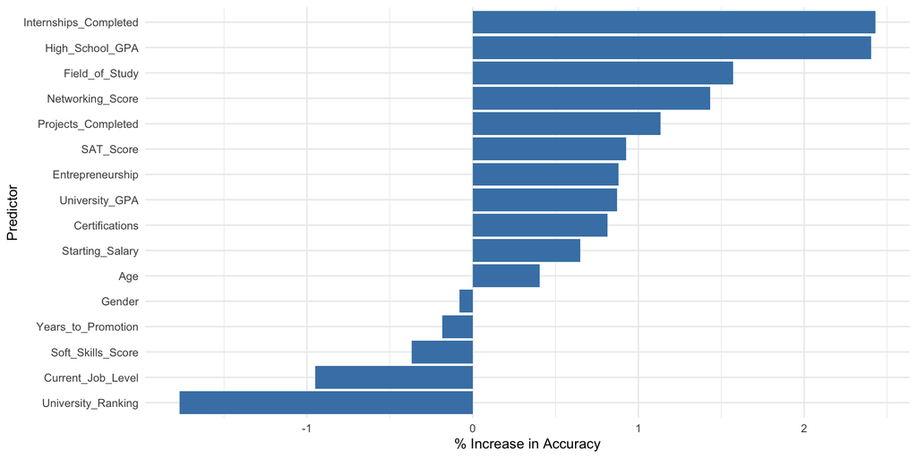

- This plot shows the importance of each predictor variable in the **random forest model** by using permutation.
- The result shows that most important factors are related to your **academic performance** and **practical experience**.
- It is also interesting to noted that **networking skill** rank much higher than **soft skills**.

## Association between important factors and job offers

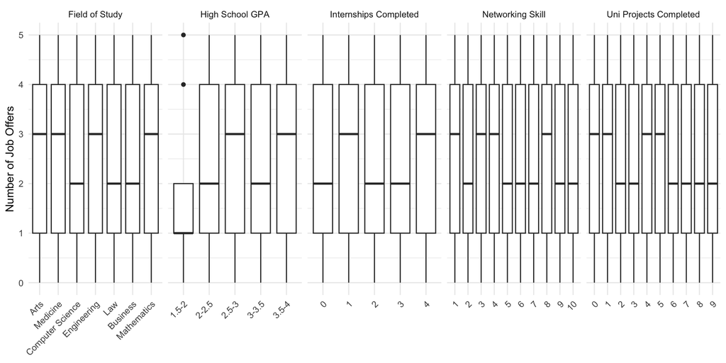

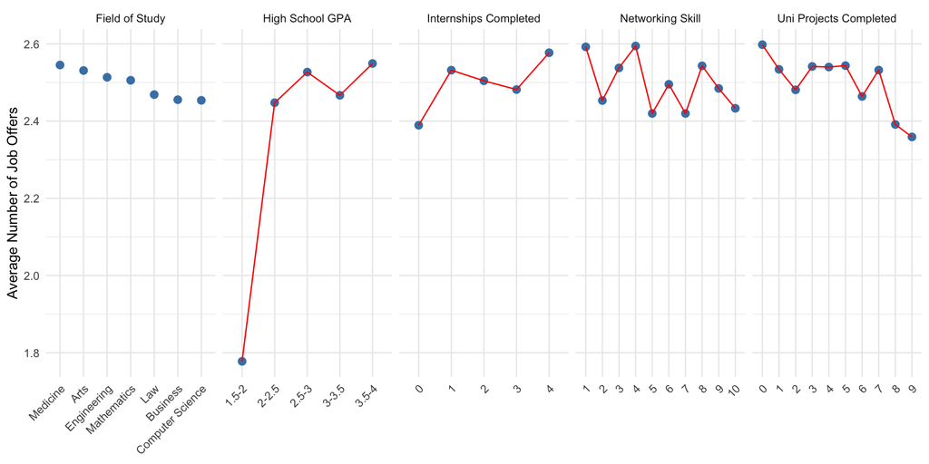

## Recommendations

- **Students** must focus on internships, GPA, and **balanced involvement** in co-curriculars.
- **Universities** should embed industry-linked experiences and align programs with job market needs.
- **Career Services** must promote strategic engagement beyond academics.